# Analytics Edge: Unit 6 - An Introduction to Clustering

Sulman Khan

October 26, 2018

## Recommendations Worth a Million

### Netflix

- Online DVD rental and steaming video service
- More than 40 million subscribers worldwide
- $3.6 billion in revenue
- Key aspect is being able to offer customers accurate movie recommendations based on customer’s own preferences and viewing history

### The Netflix Prize

- From 2006 - 2009 Netflix ran a contest asking the public to submit algorithms to predict user ratings for movies
- Training data set of ~100,000,000 ratings and test data set of ~3,000,000 ratings were provided
- Offered a grand prize of $1,000,000 USD to the team who could beat Netflix’s own algorithm, Cinematch, by more than 10%, measured in RMSE

### Predicting the Best User Ratings

- Netflix was willing to pay over $1M for the best user rating algorithm, which shows how critical the recommendation system was to their business
- What data could be used to predict user ratings?
- Every movie in Netflix’s database has the ranking from all users who have ranked that movie
- We also know facts about the movie itself, actors, directors, genre classification, year released, etc.

### Using Other Users’ Rankings

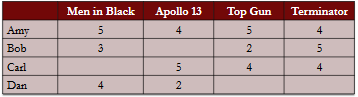

- Consider suggesting to Carl that he watch “Men in Black”, since Amy rated it highly and Carl and Amy seem to have similar preferences
- This technique is called **Collaborative Filtering**

### Using Movie Information

- We saw that Amy liked “Men In Black”
  - It was directed by Barry Sonnenfeld
  - Classified in the genres of action, adventure, sci-fi and comedy
  - It stars actor Will Smith
- Consider recommending Amy:
  - Barry Sonnenfeld’s movie “Get Shorty”
  - “Jurassic Park”, which is in the genres of action, adventure, and sci-fi
  - Will Smith’s movie “Hitch”
- This technique is called **COntent Filtering**

### Strengths and Weaknesses

- Collaborative Filtering Systems
  - Can accurately suggest complex items without understanding the nature of the items
  - Requires a lot of data about the user to make accurate recommendations
  - Millions of items - needs lots of computing power
- Content Filtering
  - Requires very little data to get started
  - Can be limited in scope

### Hybrid Recommendation Systems

- Netflix uses both collaborative and content filtering
- For example, consider a collaborative filtering approach where we determine that Amy and Carl have similar preferences
- We could then do content filtering, where we would find that “Terminator”, which both Amy and Carl liked, is classified in almost the same set of genres as “Starship Troopers”
- Recommend “Starship Troopers” to both Amy and Carl, even though neither of them have seen it before

### MovieLens Data

- [www.movielens.org](https://movielens.org/) is a movie recommendation website run by GroupLens Research Lab at the University of Minnesota
- They collect user preferences about movies and do collaborative filtering to make recommendations we will use their movie database to do content filtering using a technique called clustering

### Why Clustering?

- “Unsupervised” learning
  - Goal is to segment the data into similar groups instead of prediction
- Can also cluster data into “similar” groups and then build a predictive model for each group
  - Be careful not to overfit your model! This works best with large data sets

### Types of Clustering Methods

- There are many different algorithms for clustering
  - Differ in what makes a cluster and how to find them
- We will cover
  - Hierarchical
  - K-means

### Distance Between Points

- Need to define distance between two data data points
  - Most popular is “Euclidean distance”
  - Distance between points i and j is
    $$d_ij = \sqrt[2][(x_{i,1} - x_{j,1})^2 + (x_{i,2} - x_{j,2})^2 + ... + (x_{ik} - x_{jk})^2]$$
    where k is the number of independent variables

### Distance Example

- The movie “Toy Story” is categorized as Animation, Comedy, and Children
  - Toy Story: (0,0,0,1,1,1,0,0,0,0,0,0,0,0,0,0,0,0,0)
- The movie “Batman Forever” is categorized as Action, Adventure, Comedy, and Crime
  - Batman Forever: (0,1,1,0,0,1,1,0,0,0,0,0,0,0,0,0,0,0,0)

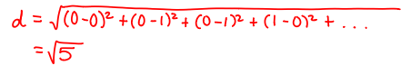

- Other popular distance metrics:
  - Manhattan Distance
    - Sum of absolute values instead of squares
  - Maximum Coordinate Distance
    - Only consider measurement for which data points deviate the most

### Distance Between Clusters

- Minimum Distance
  - Distance between clusters is the distance between points that are the closest

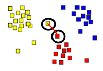

- Maximum Distance
  - Distance between clusters is the distance between points that are the farthest

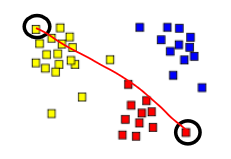

- Centroid Distance
  - Distance between centroids of clusters
    - Centroid is point that has the average of all data points in each component

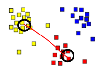

### Normalize Data

- Distance is highly influenced by scale of variables, so customary to normalize first
- In our movie dataset, all genre variables are on the same scale and so normalization is not necessary
- However, if we included a variable such as “Box Office Revenue”, we would need to normalize

### Hierarchical

- Start with each data point in its own cluster

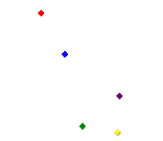

- Combine two nearest clusters (Euclidean, Centroid)

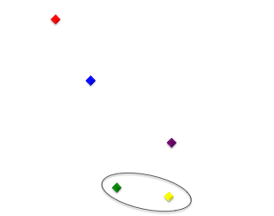

### Display Cluster Process

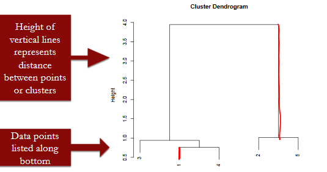

### Select Clusters

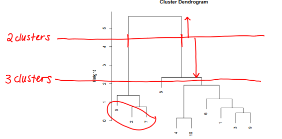

### Meaningful Clusters?

- Look at statistics (mean, min, max, …) for each cluster and each variable
- See if clusters have a feature in common that was not used in the clustering (like an outcome)

### The Edge of Recommendation Systems

- In today’s digital age, businesses often have hundreds of thousands of items to offer their customers
- Excellent recommendation systems can make or break these businesses
- Clustering algorithms, which are tailored to find similar customers or similar items, form the backbone of many of these recommendation systems.

## Netflix in R

### Introduction to Clustering

#### Load the data into R

```r
# Load the dataset
movies = read.table("movieLens.txt", header=FALSE, sep="|",quote="\"")
# Output the string of the dataset
str(movies)
```

```
## 'data.frame':    1682 obs. of  24 variables:
##  $ V1 : int  1 2 3 4 5 6 7 8 9 10 ...
##  $ V2 : Factor w/ 1664 levels "'Til There Was You (1997)",..: 1525 618 555 594 344 1318 1545 111 391 1240 ...
##  $ V3 : Factor w/ 241 levels "","01-Aug-1997",..: 71 71 71 71 71 71 71 71 71 182 ...
##  $ V4 : logi  NA NA NA NA NA NA ...
##  $ V5 : Factor w/ 1661 levels "","http://us.imdb.com/M/title-exact/Independence%20(1997)",..: 1431 565 505 543 310 1661 1453 103 357 1183 ...
##  $ V6 : int  0 0 0 0 0 0 0 0 0 0 ...
##  $ V7 : int  0 1 0 1 0 0 0 0 0 0 ...
##  $ V8 : int  0 1 0 0 0 0 0 0 0 0 ...
##  $ V9 : int  1 0 0 0 0 0 0 0 0 0 ...
##  $ V10: int  1 0 0 0 0 0 0 1 0 0 ...
##  $ V11: int  1 0 0 1 0 0 0 1 0 0 ...
##  $ V12: int  0 0 0 0 1 0 0 0 0 0 ...
##  $ V13: int  0 0 0 0 0 0 0 0 0 0 ...
##  $ V14: int  0 0 0 1 1 1 1 1 1 1 ...
##  $ V15: int  0 0 0 0 0 0 0 0 0 0 ...
##  $ V16: int  0 0 0 0 0 0 0 0 0 0 ...
##  $ V17: int  0 0 0 0 0 0 0 0 0 0 ...
##  $ V18: int  0 0 0 0 0 0 0 0 0 0 ...
##  $ V19: int  0 0 0 0 0 0 0 0 0 0 ...
##  $ V20: int  0 0 0 0 0 0 0 0 0 0 ...
##  $ V21: int  0 0 0 0 0 0 1 0 0 0 ...
##  $ V22: int  0 1 1 0 1 0 0 0 0 0 ...
##  $ V23: int  0 0 0 0 0 0 0 0 0 1 ...
##  $ V24: int  0 0 0 0 0 0 0 0 0 0 ...
```

#### Add column names

```r
# Add column names
colnames(movies) = c("ID", "Title", "ReleaseDate", "VideoReleaseDate", "IMDB", "Unknown", "Action", "Adventure", "Animation", "Childrens", "Comedy", "Crime", "Documentary", "Drama", "Fantasy", "FilmNoir", "Horror", "Musical", "Mystery", "Romance", "SciFi", "Thriller", "War", "Western")
# Outputs the string
str(movies)
```

```
## 'data.frame':    1682 obs. of  24 variables:
##  $ ID              : int  1 2 3 4 5 6 7 8 9 10 ...
##  $ Title           : Factor w/ 1664 levels "'Til There Was You (1997)",..: 1525 618 555 594 344 1318 1545 111 391 1240 ...
##  $ ReleaseDate     : Factor w/ 241 levels "","01-Aug-1997",..: 71 71 71 71 71 71 71 71 71 182 ...
##  $ VideoReleaseDate: logi  NA NA NA NA NA NA ...
##  $ IMDB            : Factor w/ 1661 levels "","http://us.imdb.com/M/title-exact/Independence%20(1997)",..: 1431 565 505 543 310 1661 1453 103 357 1183 ...
##  $ Unknown         : int  0 0 0 0 0 0 0 0 0 0 ...
##  $ Action          : int  0 1 0 1 0 0 0 0 0 0 ...
##  $ Adventure       : int  0 1 0 0 0 0 0 0 0 0 ...
##  $ Animation       : int  1 0 0 0 0 0 0 0 0 0 ...
##  $ Childrens       : int  1 0 0 0 0 0 0 1 0 0 ...
##  $ Comedy          : int  1 0 0 1 0 0 0 1 0 0 ...
##  $ Crime           : int  0 0 0 0 1 0 0 0 0 0 ...
##  $ Documentary     : int  0 0 0 0 0 0 0 0 0 0 ...
##  $ Drama           : int  0 0 0 1 1 1 1 1 1 1 ...
##  $ Fantasy         : int  0 0 0 0 0 0 0 0 0 0 ...
##  $ FilmNoir        : int  0 0 0 0 0 0 0 0 0 0 ...
##  $ Horror          : int  0 0 0 0 0 0 0 0 0 0 ...
##  $ Musical         : int  0 0 0 0 0 0 0 0 0 0 ...
##  $ Mystery         : int  0 0 0 0 0 0 0 0 0 0 ...
##  $ Romance         : int  0 0 0 0 0 0 0 0 0 0 ...
##  $ SciFi           : int  0 0 0 0 0 0 1 0 0 0 ...
##  $ Thriller        : int  0 1 1 0 1 0 0 0 0 0 ...
##  $ War             : int  0 0 0 0 0 0 0 0 0 1 ...
##  $ Western         : int  0 0 0 0 0 0 0 0 0 0 ...
```

#### Remove unnecessary variables

```r
# Remove unecessary variables
movies$ID = NULL
movies$ReleaseDate = NULL
movies$VideoReleaseDate = NULL
movies$IMDB = NULL
```

#### Remove duplicates

```r
# Remove duplicates
movies = unique(movies)
```

#### Take a look at our data again:

```r
# Examine the string
str(movies)
```

```
## 'data.frame':    1664 obs. of  20 variables:
##  $ Title      : Factor w/ 1664 levels "'Til There Was You (1997)",..: 1525 618 555 594 344 1318 1545 111 391 1240 ...
##  $ Unknown    : int  0 0 0 0 0 0 0 0 0 0 ...
##  $ Action     : int  0 1 0 1 0 0 0 0 0 0 ...
##  $ Adventure  : int  0 1 0 0 0 0 0 0 0 0 ...
##  $ Animation  : int  1 0 0 0 0 0 0 0 0 0 ...
##  $ Childrens  : int  1 0 0 0 0 0 0 1 0 0 ...
##  $ Comedy     : int  1 0 0 1 0 0 0 1 0 0 ...
##  $ Crime      : int  0 0 0 0 1 0 0 0 0 0 ...
##  $ Documentary: int  0 0 0 0 0 0 0 0 0 0 ...
##  $ Drama      : int  0 0 0 1 1 1 1 1 1 1 ...
##  $ Fantasy    : int  0 0 0 0 0 0 0 0 0 0 ...
##  $ FilmNoir   : int  0 0 0 0 0 0 0 0 0 0 ...
##  $ Horror     : int  0 0 0 0 0 0 0 0 0 0 ...
##  $ Musical    : int  0 0 0 0 0 0 0 0 0 0 ...
##  $ Mystery    : int  0 0 0 0 0 0 0 0 0 0 ...
##  $ Romance    : int  0 0 0 0 0 0 0 0 0 0 ...
##  $ SciFi      : int  0 0 0 0 0 0 1 0 0 0 ...
##  $ Thriller   : int  0 1 1 0 1 0 0 0 0 0 ...
##  $ War        : int  0 0 0 0 0 0 0 0 0 1 ...
##  $ Western    : int  0 0 0 0 0 0 0 0 0 0 ...
```

#### Compute distances

```r
# Compute euclidean distance
distances = dist(movies[2:20], method = "euclidean")
```

#### Hierarchical clustering

```r
# Implement hierarchical clustering algorithm
clusterMovies = hclust(distances, method = "ward")
```

#### Plot the dendrogram

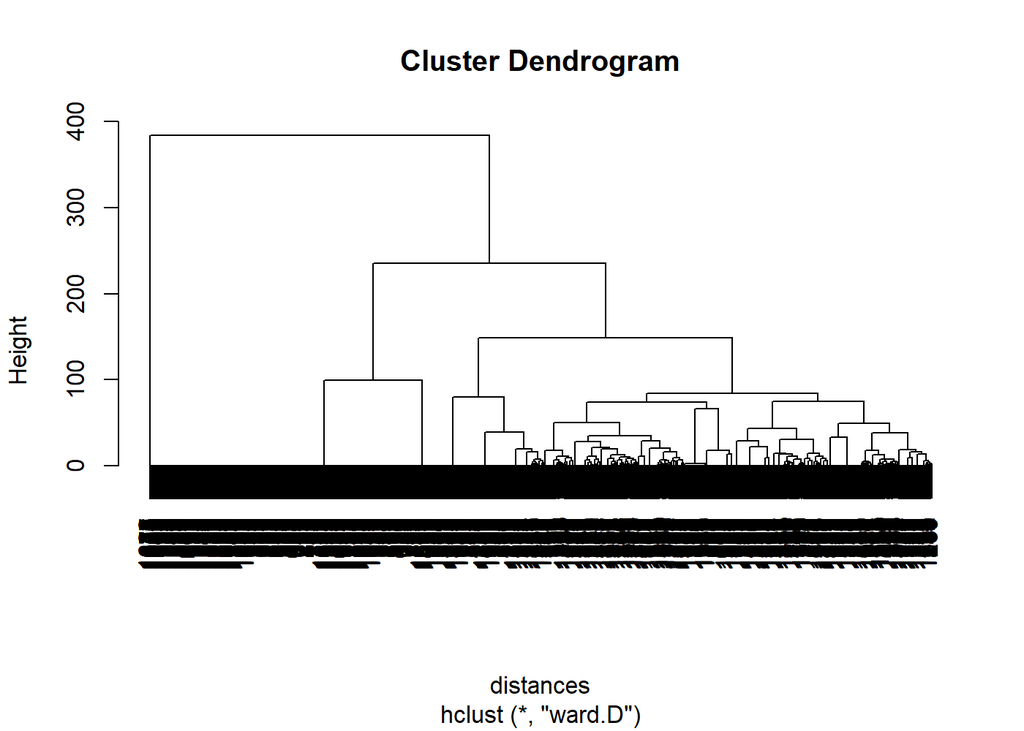

```r
# Plot the dendrogram
plot(clusterMovies)
```

#### Assign points to clusters

```r
# Divide the points into 10 clusters
clusterGroups = cutree(clusterMovies, k = 10)
```

#### Let’s use the tapply function to compute the percentage of movies in each genre and cluster

```r
# Compare two different categories using a statistical measure
z = tapply(movies$Action, clusterGroups, mean)
x = c(1, 2, 3, 4, 5, 6, 7, 8, 9, 10)
y = cbind(x,z)
kable(y)
```

| x | z |
| --- | --- |
| 1 | 0.1784512 |
| 2 | 0.7839196 |
| 3 | 0.1238532 |
| 4 | 0.0000000 |
| 5 | 0.0000000 |
| 6 | 0.1015625 |
| 7 | 0.0000000 |
| 8 | 0.0000000 |
| 9 | 0.0000000 |
| 10 | 0.0000000 |

```r
z = tapply(movies$Romance, clusterGroups, mean)
y = cbind(x,z)
kable(y)
```

| x | z |
| --- | --- |
| 1 | 0.1043771 |
| 2 | 0.0452261 |
| 3 | 0.0366972 |
| 4 | 0.0000000 |
| 5 | 0.0000000 |
| 6 | 1.0000000 |
| 7 | 1.0000000 |
| 8 | 0.0000000 |
| 9 | 0.0000000 |
| 10 | 0.0000000 |

We can repeat this for each genre. If you do, you get the results in ClusterMeans.ods

#### Find which cluster Men in Black is in.

```r
# Find which subset men in black is in
z = subset(movies, Title=="Men in Black (1997)")
kable(z)
```

|  | Title | Unknown | Action | Adventure | Animation | Childrens | Comedy | Crime | Documentary | Drama | Fantasy | FilmNoir | Horror | Musical | Mystery | Romance | SciFi | Thriller | War | Western |
| --- | --- | --- | --- | --- | --- | --- | --- | --- | --- | --- | --- | --- | --- | --- | --- | --- | --- | --- | --- | --- |
| 257 | Men in Black (1997) | 0 | 1 | 1 | 0 | 0 | 1 | 0 | 0 | 0 | 0 | 0 | 0 | 0 | 0 | 0 | 1 | 0 | 0 | 0 |

```r
clusterGroups[257]
## 257
##   2
```

#### Create a new data set with just the movies from cluster 2

```r
# Create a subset with movies from cluster 2
cluster2 = subset(movies, clusterGroups==2)
```

#### Look at the first 10 titles in this cluster:

```r
# Examine the first 10 titles in the cluster
z = cluster2$Title[1:10]
kable(z)
```

| x |
| --- |
| GoldenEye (1995) |
| Bad Boys (1995) |
| Apollo 13 (1995) |
| Net, The (1995) |
| Natural Born Killers (1994) |
| Outbreak (1995) |
| Stargate (1994) |
| Fugitive, The (1993) |
| Jurassic Park (1993) |
| Robert A. Heinlein’s The Puppet Masters (1994) |